# Exploring the BRFSS data

## Setup

### Load packages

```r
library(ggplot2)
library(dplyr)
```

### Load data

```r
load("brfss2013.RData")
```

## Part 1: Data

The Behavioral Risk Factor Surveillance System (BRFSS) is a collaborative project between all of the states in the United States (US) and participating US territories and the Centers for Disease Control and Prevention (CDC). The BRFSS objective is to collect uniform, state-specific data on preventive health practices and risk behaviors that are linked to chronic diseases, injuries, and preventable infectious diseases that affect the adult population.

Since 2011, BRFSS conducts both landline telephone- and cellular telephone-based surveys. In conducting the BRFSS landline telephone survey, interviewers collect data from a randomly selected adult in a household. In conducting the cellular telephone version of the BRFSS questionnaire, interviewers collect data from an adult who participates by using a cellular telephone and resides in a private residence or college housing.

The data collection method involved random sampling for the landline telephone survey but I am not sure if the cellular telephone version involved random sampling. Overall, since this is an observational study with some random sampling I can say the results from this project may be generalizable but we cannot infer causation - only association.

## Part 2: Research questions

In summary, my research questions look at the variability of alcohol consumption, tobacco use and exercise across states in the United States. Below I discuss them in detail. Please note that the dataset contains missing values. For my exploratory data analysis, I chose to drop these observations.

**Research quesion 1:**

My first research question aims to examine how much alcohol is consumed across each US state and territory. I would like to see which states and territories of the US have the highest rates of alcohol use and its variability. The variables I will use are:

- _state: State FIPS Code
- avedrnk2: Avg alcoholic drinks per day in past 30 days
- maxdrinks: Most drinks on single occasion past 30 days

**Research quesion 2:**

My second research question will look at distribution of tobacco use across each US state and territory. My aim to compute the counts of smokers and non-smokers for each state/territory in the dataset. The variables I will use are:

- _state: State FIPS Code
- smoke100: Smoked at least 100 cigarettes (categorical variable)
- smokday2: Frequency of days now smoking (categorical variable)

**Research quesion 3:**

The aim of my third research question is to identify the most popular physical activity across each US state and territory. This interests me because regular exercise has been linked with a healthier lifestyle. So, I would like to see the most popular physical activity for each state/territory by percentage.

- _state: State FIPS Code
- exract11 : Type of physical activity

## Part 3: Exploratory data analysis

Before I start my Exploratory Data Analysis, there are two rows in the dataset - 0 and 80 which I filtered out

```r
data <- brfss2013 %>% filter(X_state != 0, X_state != 80)
```

**Research quesion 1:**

First, we look at summary statistics for average alcoholic drink per day for the last 30 days

```r
summary_stats <- data %>% group_by(X_state) %>% summarise(mean = mean(avedrnk2, na.rm=TRUE), median = median(avedrnk2, na.rm=TRUE), sd = sd(avedrnk2, na.rm=TRUE), min = min(avedrnk2, na.rm=TRUE), max = max(avedrnk2, na.rm=TRUE), count = n())

#The state/territory with the highest daily average alcoholic drinks consumption per day in the past 30 days
summary_stats %>% arrange(desc(mean))
```

```
## Source: local data frame [53 x 7]
##
##          X_state     mean median       sd   min   max count
##           <fctr>    <dbl>  <dbl>    <dbl> <int> <int> <int>
## 1    Puerto Rico 4.657199      3 4.604740     1    50  5997
## 2           Guam 3.710598      3 3.863902     1    42  1897
## 3         Hawaii 2.705577      2 3.090691     1    48  7858
## 4           Utah 2.623815      2 2.856273     1    48 12769
## 5  West Virginia 2.500000      2 2.238724     1    26  5899
## 6   North Dakota 2.490892      2 2.518286     1    50  7806
## 7    Mississippi 2.489054      2 3.279500     1    60  7453
## 8       Kentucky 2.453189      2 2.718943     1    53 10877
## 9      Wisconsin 2.439402      2 2.465985     1    45  6589
## 10         Texas 2.420440      2 2.428452     1    30 10917
## ..           ...      ...    ...      ...   ...   ...   ...
```

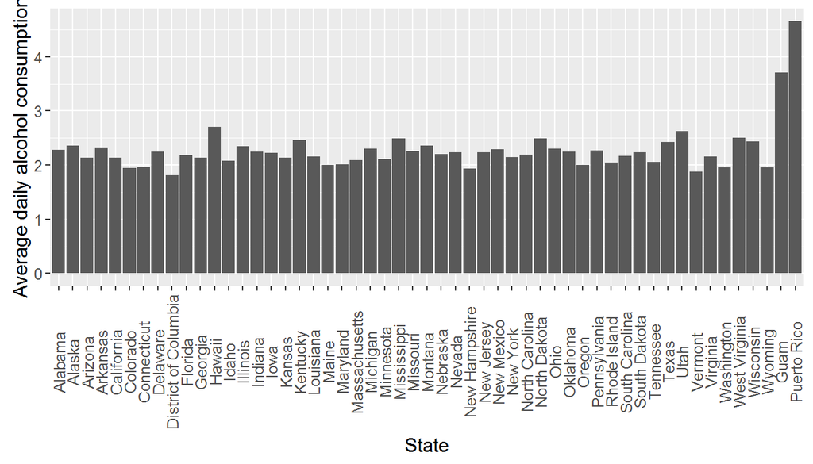

```r
#Bar chart of the average daily consumption of alcohol by state
ggplot(data = summary_stats, aes(x = X_state, y = mean)) + geom_bar(stat = "identity") + theme(text = element_text(size = 12), axis.text.x = element_text(angle = 90, vjust = 0.5)) + xlab("State") + ylab("Average daily alcohol consumption")
```

`Puerto Rico` and `Guam` have the highest and second highest average daily consumption of alcoholic drinks respectively while for the other states/territories in the United States the average alcoholic drinks consumption is roughly uniform.

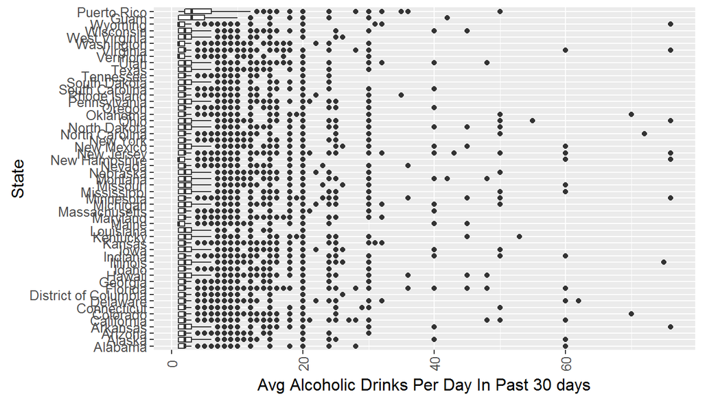

```r
#Boxplot showing variablity of daily alcohol consumption by state
ggplot(data = data, aes(x = X_state, y = avedrnk2)) + geom_boxplot() + coord_flip() + theme(text = element_text(size = 12), axis.text.x = element_text(angle = 90, vjust = 0.5)) + xlab("State") + ylab("Avg Alcoholic Drinks Per Day In Past 30 days")
```

Although the boxplot is not very clear, `Puerto Rico` and `Guam` have the highest variability of average daily alcohol consumption (I zoomed it on RStudio, I don’t know how to do it here). Furthermore, all the states/territories have a considerable number of outliers.

Next, we look at the summary statistics for the variable *maxdrinks* - Most drinks on a single occassion in the past 30 days

```r
summary_stats <- data %>% group_by(X_state) %>% summarise(mean = mean(maxdrnks, na.rm=TRUE), median = median(maxdrnks, na.rm=TRUE), sd = sd(maxdrnks, na.rm=TRUE), min = min(maxdrnks, na.rm=TRUE), max = max(maxdrnks, na.rm=TRUE), count = n())

#The state/territory with the highest average alcoholic drinks consumed on a single occassion in the past 30 days
summary_stats %>% arrange(desc(mean))
```

```
## Source: local data frame [53 x 7]
##
##          X_state     mean median       sd   min   max count
##           <fctr>    <dbl>  <dbl>    <dbl> <int> <int> <int>
## 1           Guam 5.319602      3 5.855429     1    64  1897
## 2    Puerto Rico 4.406520      3 3.621637     1    30  5997
## 3         Hawaii 3.988424      3 4.301208     1    53  7858
## 4           Utah 3.973309      3 4.093182     1    50 12769
## 5   North Dakota 3.830465      3 3.889485     1    52  7806
## 6  West Virginia 3.808104      2 4.336985     1    40  5899
## 7      Wisconsin 3.687981      2 3.664509     1    63  6589
## 8        Montana 3.664977      2 3.840908     1    70  9693
## 9         Alaska 3.630416      3 3.532886     1    52  4578
## 10      Illinois 3.543624      2 3.590452     1    50  5608
## ..           ...      ...    ...      ...   ...   ...   ...
```

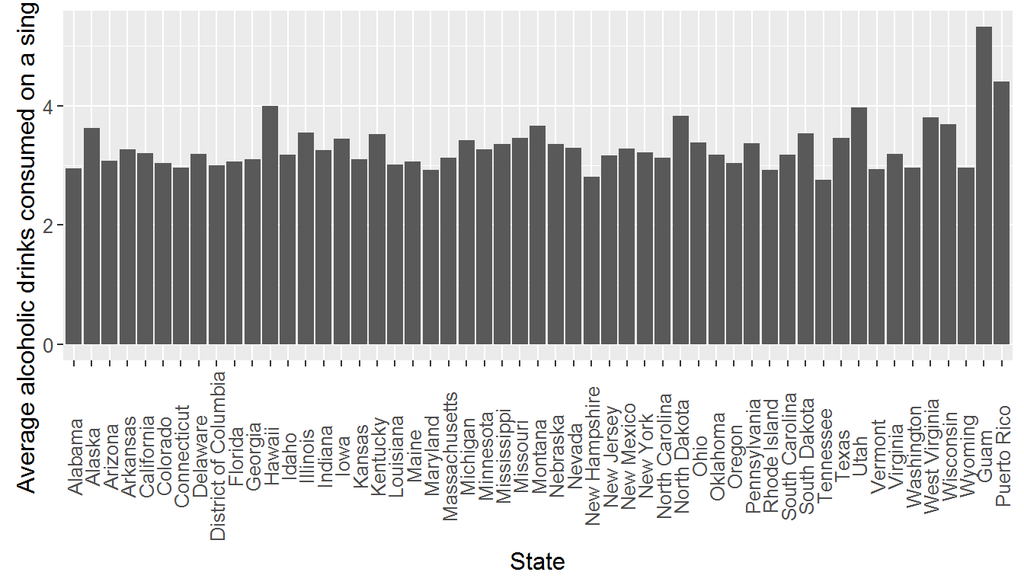

```r
#Bar chart of average alcoholic drinks consumed on a single occassion in the past 30 days
ggplot(data = summary_stats, aes(x = X_state, y = mean)) + geom_bar(stat = "identity") + theme(text = element_text(size = 12), axis.text.x = element_text(angle = 90, vjust = 0.5)) + xlab("State") + ylab("Average alcoholic drinks consumed on a single occasion")
```

Once again we see almost the same pattern but in this case `Guam` has the highest while `Puerto Rico` has the second highest consumption of alcoholic drinks on a single occasion while for the other states of the US it’s roughly uniform.

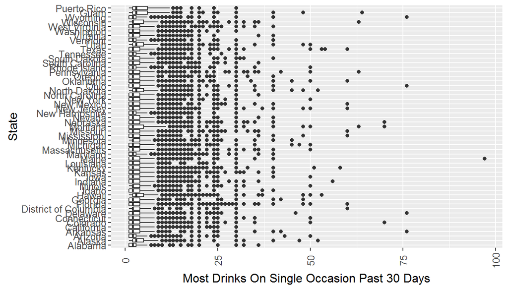

```r
#Boxplot showing variablity of Most Drinks on a Single Occasion in the past 30 days
ggplot(data = data, aes(x = X_state, y = maxdrnks)) + geom_boxplot() + coord_flip() + theme(text = element_text(size = 12), axis.text.x = element_text(angle = 90, vjust = 0.5)) + xlab("State") + ylab("Most Drinks On Single Occasion Past 30 Days")
```

From the boxplot we can see that *maxdrnks* has more variability for each state compared to the *avedrnk2*. Again, we see that all states have a considerable amount of outliers.

**Research quesion 2:**

Next, we examine the distribution of tobacco use by state. First, let’s look at the counts for the variable *smoke100* - Smoked at least 100 cigarettes. It has two levels - “Yes” or “No”

```r
#Lets get counts of the two levels of this variable for each state/territory
smoke100_counts <- data %>% group_by(X_state, smoke100) %>% filter(!is.na(smoke100)) %>% summarise(count = n())

#The states with the highest "Yes" responses
smoke100_counts %>% filter(smoke100 == "Yes") %>% arrange(desc(count))
```

```
## Source: local data frame [53 x 3]
## Groups: X_state [53]
##
##          X_state smoke100 count
##           <fctr>   <fctr> <int>
## 1        Florida      Yes 16391
## 2         Kansas      Yes 10122
## 3       Nebraska      Yes  7104
## 4  Massachusetts      Yes  6655
## 5      Minnesota      Yes  6268
## 6       Michigan      Yes  5998
## 7     New Jersey      Yes  5738
## 8       Colorado      Yes  5691
## 9           Ohio      Yes  5519
## 10      Maryland      Yes  5344
## ..           ...      ...   ...
```

```r
#The states with the highest "No" responses
smoke100_counts %>% filter(smoke100 == "No") %>% arrange(desc(count))
```

```
## Source: local data frame [53 x 3]
## Groups: X_state [53]
##
##          X_state smoke100 count
##           <fctr>   <fctr> <int>
## 1        Florida       No 16191
## 2         Kansas       No 12782
## 3       Nebraska       No  9593
## 4           Utah       No  9041
## 5  Massachusetts       No  7626
## 6      Minnesota       No  7545
## 7       Maryland       No  7256
## 8     New Jersey       No  7246
## 9       Colorado       No  7093
## 10    California       No  6564
## ..           ...      ...   ...
```

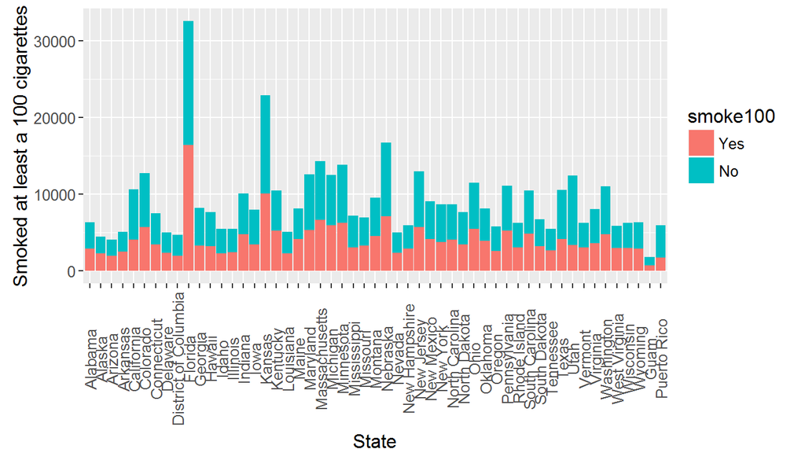

```r
#Barplots of responses to smoke100
ggplot(data = smoke100_counts, aes(x = X_state, y = count, fill = smoke100)) + geom_bar(stat="identity") + theme(text = element_text(size = 12), axis.text.x = element_text(angle = 90, vjust = 0.5)) + xlab("State") + ylab("Smoked at least a 100 cigarettes")
```

From the counts of the “Yes” responses, `Florida` and `Kansas` have the highest number of people who have smoked at least a 100 cigarettes in the dataset. From the counts of “No” responses, `Florida` and `Kansas` also have the highest number of people who have not smoked at least a 100 cigarettes.

Next, let us look at the counts for the levels of the variable *smokday2* - Frequency of days now smoking. It has three levels - “Every day”, “Some days” and “Not at all”

```r
smokday2_counts <- data %>% group_by(X_state, smokday2) %>% filter(!is.na(smokday2)) %>% summarise(count = n())

#States with the highest non-smokers
smokday2_counts %>% filter(smokday2 == "Not at all") %>% arrange(desc(count))
```

```
## Source: local data frame [53 x 3]
## Groups: X_state [53]
##
##          X_state   smokday2 count
##           <fctr>     <fctr> <int>
## 1        Florida Not at all 11018
## 2         Kansas Not at all  6244
## 3       Nebraska Not at all  4541
## 4  Massachusetts Not at all  4466
## 5      Minnesota Not at all  4247
## 6       Michigan Not at all  3851
## 7       Colorado Not at all  3850
## 8     New Jersey Not at all  3717
## 9       Maryland Not at all  3656
## 10    Washington Not at all  3369
## ..           ...        ...   ...
```

```r
#States with the highest daily smokers
smokday2_counts %>% filter(smokday2 == "Every day") %>% arrange(desc(count))
```

```
## Source: local data frame [53 x 3]
## Groups: X_state [53]
##
##          X_state  smokday2 count
##           <fctr>    <fctr> <int>
## 1        Florida Every day  3811
## 2         Kansas Every day  2884
## 3       Nebraska Every day  1891
## 4           Ohio Every day  1818
## 5       Kentucky Every day  1795
## 6       Michigan Every day  1569
## 7  Massachusetts Every day  1545
## 8   Pennsylvania Every day  1500
## 9      Minnesota Every day  1405
## 10       Indiana Every day  1403
## ..           ...       ...   ...
```

```r
#States with the highest occasional smokers
smokday2_counts %>% filter(smokday2 == "Some days") %>% arrange(desc(count))
```

```
## Source: local data frame [53 x 3]
## Groups: X_state [53]
##
##          X_state  smokday2 count
##           <fctr>    <fctr> <int>
## 1        Florida Some days  1512
## 2         Kansas Some days   981
## 3       Nebraska Some days   662
## 4     New Jersey Some days   642
## 5  Massachusetts Some days   637
## 6      Minnesota Some days   597
## 7       Colorado Some days   587
## 8       Michigan Some days   574
## 9           Ohio Some days   553
## 10      Kentucky Some days   552
## ..           ...       ...   ...
```

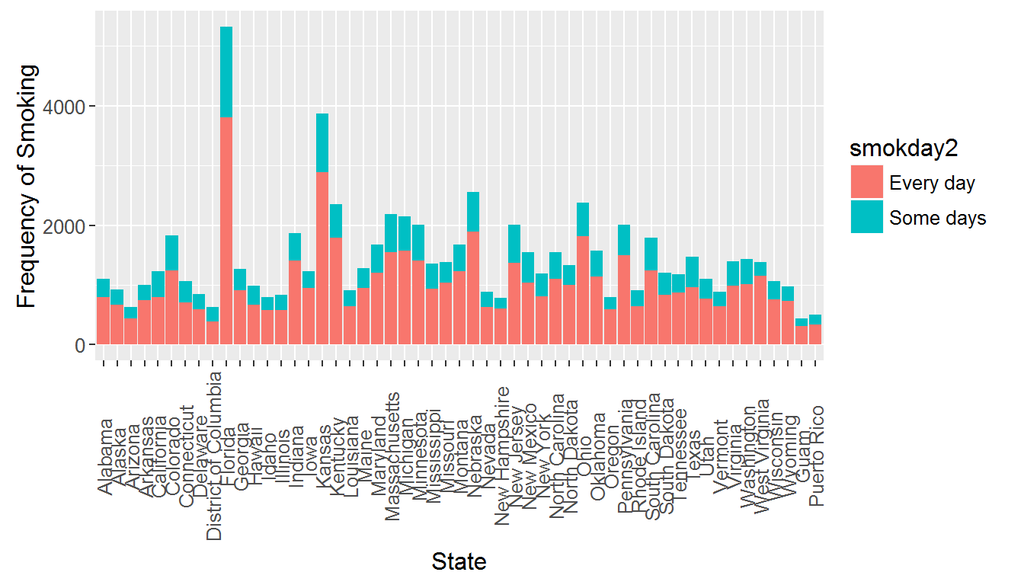

```r
#Plot of "Every day" or "Some days" responses by state
smokers <- smokday2_counts %>% filter(smokday2 != "Not at all")

ggplot(data = smokers, aes(x = X_state, y = count, fill = smokday2)) + geom_bar(stat="identity") + theme(text = element_text(size = 12), axis.text.x = element_text(angle = 90, vjust = 0.5)) + xlab("State") + ylab("Frequency of Smoking")
```

`Florida` has the highest counts of occasional, daily and non-smokers in the dataset. The barplot also shows that among smokers for each state, daily smokers are more than occasional smokers.

**Research quesion 3:** Finally, we look at the most popular physical actvity for each state by percentage.

```r
#Dataframe that contains counts for physical activities in each state
exer_counts <- data %>% group_by(X_state, exract11) %>% filter(!is.na(exract11)) %>% summarise(count = n())

#First compute the counts of the most popular physical activity for each state i.e. the maximum
max_counts <- aggregate(count ~ X_state, exer_counts, FUN = max)

#Then compute the sum of counts of all physical activities for each state
sum_counts <- aggregate(count ~ X_state, exer_counts, FUN = sum)

#Merge max_counts dataframe with the original dataframe
combined_df <- merge(max_counts, exer_counts)

#Finally merge this dataframe with the sum_counts dataframe
all_df <- merge(combined_df, sum_counts, by = "X_state")

#Re-order the dataframe
all_df <- all_df[, c(1, 3, 2, 4)]

#Change the column names
names(all_df) <- c("State", "Most popular exercise", "Max", "Sum")
#Max is the counts for the most popular physical activity
#Sum is the sum of counts of all physical activities for each state

#Create column that represents percentage of population that take part in this activity
all_df <- all_df %>% mutate(average = Max/Sum)

#Show first 10 rows of the dataframe
head(all_df, n = 10)
```

```
##                   State Most popular exercise   Max   Sum   average
## 1               Alabama               Walking  2521  4079 0.6180436
## 2                Alaska               Walking  1731  3271 0.5291960
## 3               Arizona               Walking  1590  2846 0.5586788
## 4              Arkansas               Walking  1910  3077 0.6207345
## 5            California               Walking  4032  8080 0.4990099
## 6              Colorado               Walking  5107 10042 0.5085640
## 7           Connecticut               Walking  2791  5339 0.5227571
## 8              Delaware               Walking  1797  3460 0.5193642
## 9  District of Columbia               Walking  1909  3550 0.5377465
## 10              Florida               Walking 11610 21613 0.5371767
```

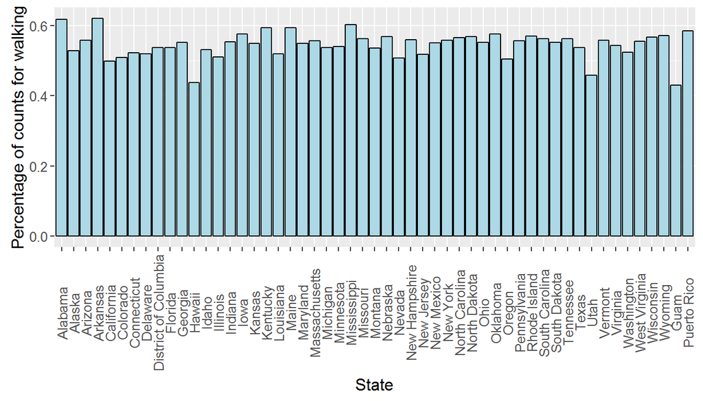

```r
#Barplot of average
ggplot(data = all_df, aes(x = State, y = average)) + geom_bar(stat="identity", fill = "lightblue", colour = "black") + theme(text = element_text(size = 12), axis.text.x = element_text(angle = 90, vjust = 0.5)) + xlab("State") + ylab("Percentage of counts for walking")
```

We can see that `walking` is the most popular activity for every state and territory of the US with at least 40% or more of respondents in each state engaging in this physical activity. `Arkansas` has the highest percentage of people who engage in walking as a physical activity while `Guam` has the lowest.